# Data_Analysis_Project_Using_Python

Zomato has an average of 17.5 million monthly transacting customers for its food delivery business.e average monthly active food delivery restaurant partners on Zomato's platform have also increased by 8.7% year-on-year, from 208,000 to 226,000.You are working in a data-driven role at Zomato. You have a dataset of customers. As a data professional, you need to analyze the data, perform EDA (Exploratory Data Analysis) and visualization, and answer the following questions:

- What type of restaurant do the majority of customers order from?
- How many votes has each type of restaurant received from customers?
- What are the ratings that the majority of restaurants have received?
- Zomato has observed that most couples order most of their food online. What is their

average spending on each order?

- Which mode (online or offline) has received the maximum rating?
- Which type of restorent recieved more offline orders, so that Zomato can p customers with some good offers?

**Zomato Data Analysis Using Python**

**Step 1: Import necessary Python libraries.**

```python
import pandas as pd
import numpy as np
import matplotlib.pyplot as plt
import seaborn as sns
```

- pandas is used for data manipulation and analysis.
- numpy is used for numerical operations.
- matplotlib.pyplot and seaborn are used for data visualization.

**Step 2: Create the data frame.**

```python
dataframe = pd.read_csv(r"C:\Users\Prathamesh Jadhav\Documents\PROJECTS\ZOMATO DATA ANYLICES\Zomato data .csv")
dataframe
```

|  | name | online_order | book_table | rate | votes | approx_cost(for two people) | listed_in(type) |
| --- | --- | --- | --- | --- | --- | --- | --- |
| 0 | Jalsa | Yes | Yes | 4.1/5 | 775 | 800 | Buffet |
| 1 | Spice Elephant | Yes | No | 4.1/5 | 787 | 800 | Buffet |
| 2 | San Churro Cafe | Yes | No | 3.8/5 | 918 | 800 | Buffet |
| 3 | Addhuri Udupi Bhojana | No | No | 3.7/5 | 88 | 300 | Buffet |
| 4 | Grand Village | No | No | 3.8/5 | 166 | 600 | Buffet |
| ... | ... | ... | ... | ... | ... | ... | ... |
| 143 | Melting Melodies | No | No | 3.3/5 | 0 | 100 | Dining |
| 144 | New Indraprasta | No | No | 3.3/5 | 0 | 150 | Dining |
| 145 | Anna Kuteera | Yes | No | 4.0/5 | 771 | 450 | Dining |
| 146 | Darbar | No | No | 3.0/5 | 98 | 800 | Dining |
| 147 | Vijayalakshmi | Yes | No | 3.9/5 | 47 | 200 | Dining |

148 rows × 7 columns

**Convert the Data type of - 'rate' Column.**

```python
def handel_rate(values):
    value = str(values).split('/')
    value = value[0]
    return float(value)

dataframe['rate'] = dataframe['rate'].apply(handel_rate)
dataframe
```

|  | name | online_order | book_table | rate | votes | approx_cost(for two people) | listed_in(type) |
| --- | --- | --- | --- | --- | --- | --- | --- |
| 0 | Jalsa | Yes | Yes | 4.1 | 775 | 800 | Buffet |
| 1 | Spice Elephant | Yes | No | 4.1 | 787 | 800 | Buffet |
| 2 | San Churro Cafe | Yes | No | 3.8 | 918 | 800 | Buffet |
| 3 | Addhuri Udupi Bhojana | No | No | 3.7 | 88 | 300 | Buffet |
| 4 | Grand Village | No | No | 3.8 | 166 | 600 | Buffet |
| ... | ... | ... | ... | ... | ... | ... | ... |
| 143 | Melting Melodies | No | No | 3.3 | 0 | 100 | Dining |
| 144 | New Indraprasta | No | No | 3.3 | 0 | 150 | Dining |
| 145 | Anna Kuteera | Yes | No | 4.0 | 771 | 450 | Dining |
| 146 | Darbar | No | No | 3.0 | 98 | 800 | Dining |
| 147 | Vijayalakshmi | Yes | No | 3.9 | 47 | 200 | Dining |

148 rows × 7 columns

**summary of the data frame**

```python
dataframe.info()
```

```
<class 'pandas.core.frame.DataFrame'>
RangeIndex: 148 entries, 0 to 147
Data columns (total 7 columns):
 #   Column                       Non-Null Count  Dtype
---  ------                       --------------  -----
 0   name                         148 non-null    object
 1   online_order                 148 non-null    object
 2   book_table                   148 non-null    object
 3   rate                         148 non-null    float64
 4   votes                        148 non-null    int64
 5   approx_cost(for two people)  148 non-null    int64
 6   listed_in(type)              148 non-null    object
dtypes: float64(1), int64(2), object(4)
memory usage: 8.2+ KB
```

**Conclusion - There is no NULL value in dataframe.**

**Type of Resturant**

```python
dataframe.head()
```

|  | name | online_order | book_table | rate | votes | approx_cost(for two people) | listed_in(type) |
| --- | --- | --- | --- | --- | --- | --- | --- |
| 0 | Jalsa | Yes | Yes | 4.1 | 775 | 800 | Buffet |
| 1 | Spice Elephant | Yes | No | 4.1 | 787 | 800 | Buffet |
| 2 | San Churro Cafe | Yes | No | 3.8 | 918 | 800 | Buffet |
| 3 | Addhuri Udupi Bhojana | No | No | 3.7 | 88 | 300 | Buffet |
| 4 | Grand Village | No | No | 3.8 | 166 | 600 | Buffet |

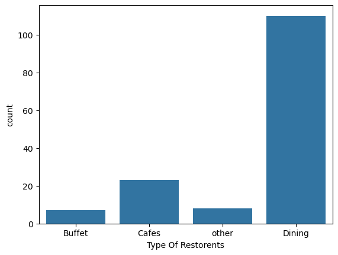

```python
sns.countplot(x=dataframe['listed_in(type)'])
plt.xlabel('Type Of Restorents')
```

**Conclusion: The majority of the restaurants fall into the dining category.**

**'Dining' restaurants are preferred by a larger number of individuals.**

```python
dataframe.head()
```

|  | name | online_order | book_table | rate | votes | approx_cost(for two people) | listed_in(type) |
| --- | --- | --- | --- | --- | --- | --- | --- |
| 0 | Jalsa | Yes | Yes | 4.1 | 775 | 800 | Buffet |
| 1 | Spice Elephant | Yes | No | 4.1 | 787 | 800 | Buffet |
| 2 | San Churro Cafe | Yes | No | 3.8 | 918 | 800 | Buffet |
| 3 | Addhuri Udupi Bhojana | No | No | 3.7 | 88 | 300 | Buffet |
| 4 | Grand Village | No | No | 3.8 | 166 | 600 | Buffet |

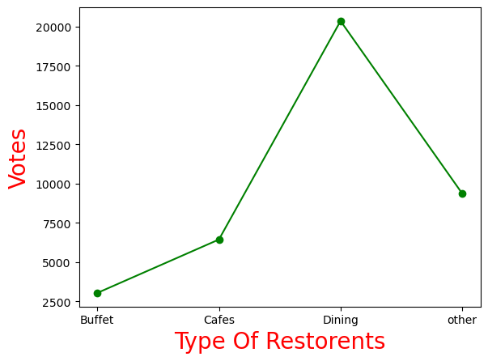

```python
gropued_data = dataframe.groupby('listed_in(type)')['votes'].sum()
result = pd.DataFrame({'votes' : gropued_data})
plt.plot(result, c='green', marker='o')
plt.xlabel('Type Of Restorents', c='red', size=20)
plt.ylabel('Votes', c='red', size=20)
```

**Conclution - 'Dining' restorents has recieved maximum votes**

```python
dataframe.head()
```

|  | name | online_order | book_table | rate | votes | approx_cost(for two people) | listed_in(type) |
| --- | --- | --- | --- | --- | --- | --- | --- |
| 0 | Jalsa | Yes | Yes | 4.1 | 775 | 800 | Buffet |
| 1 | Spice Elephant | Yes | No | 4.1 | 787 | 800 | Buffet |
| 2 | San Churro Cafe | Yes | No | 3.8 | 918 | 800 | Buffet |
| 3 | Addhuri Udupi Bhojana | No | No | 3.7 | 88 | 300 | Buffet |
| 4 | Grand Village | No | No | 3.8 | 166 | 600 | Buffet |

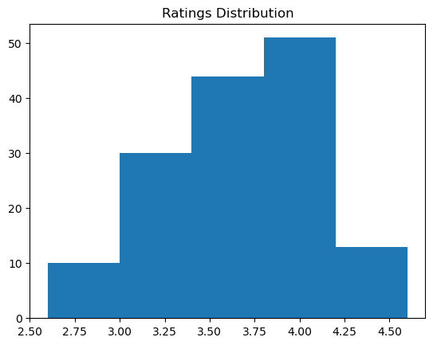

```python
plt.hist(dataframe['rate'], bins=5)
plt.title("Ratings Distribution")
plt.show()
```

**Conclusion: The majority of restaurants received ratings ranging from 3.5 to 4.**

**The majority of couples prefer restaurants with an approximate cost of 300 rupees.**

```python
dataframe.head()
```

|  | name | online_order | book_table | rate | votes | approx_cost(for two people) | listed_in(type) |
| --- | --- | --- | --- | --- | --- | --- | --- |
| 0 | Jalsa | Yes | Yes | 4.1 | 775 | 800 | Buffet |
| 1 | Spice Elephant | Yes | No | 4.1 | 787 | 800 | Buffet |
| 2 | San Churro Cafe | Yes | No | 3.8 | 918 | 800 | Buffet |
| 3 | Addhuri Udupi Bhojana | No | No | 3.7 | 88 | 300 | Buffet |
| 4 | Grand Village | No | No | 3.8 | 166 | 600 | Buffet |

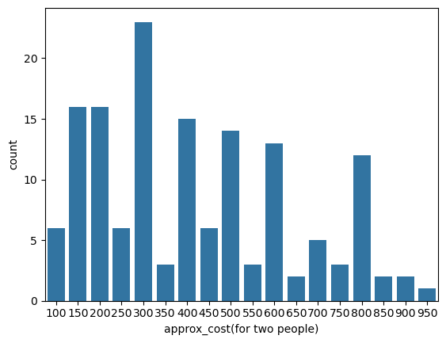

```python
couple_data = dataframe['approx_cost(for two people)']
sns.countplot(x=couple_data)
```

**whether online orders receive higher ratings than offline orders.**

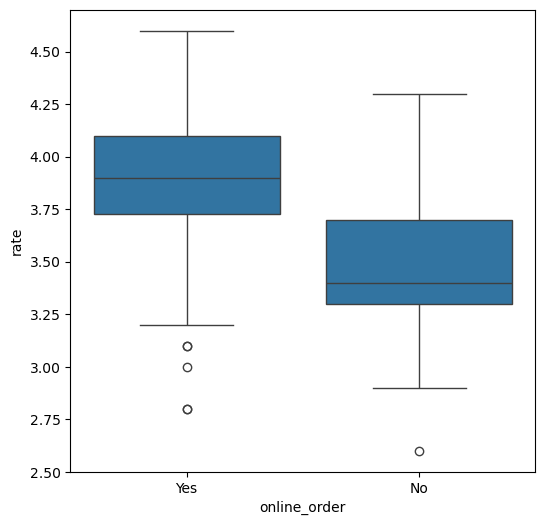

```python
plt.figure(figsize=(6,6))
sns.boxplot(x='online_order', y = 'rate', data = dataframe)
```

**Conclusion - offline order received lower rating in comparison to online order**

```python
dataframe.head()
```

|  | name | online_order | book_table | rate | votes | approx_cost(for two people) | listed_in(type) |
| --- | --- | --- | --- | --- | --- | --- | --- |
| 0 | Jalsa | Yes | Yes | 4.1 | 775 | 800 | Buffet |
| 1 | Spice Elephant | Yes | No | 4.1 | 787 | 800 | Buffet |
| 2 | San Churro Cafe | Yes | No | 3.8 | 918 | 800 | Buffet |
| 3 | Addhuri Udupi Bhojana | No | No | 3.7 | 88 | 300 | Buffet |
| 4 | Grand Village | No | No | 3.8 | 166 | 600 | Buffet |

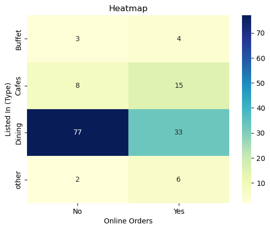

```python
pivot_table = dataframe.pivot_table(index='listed_in(type)', columns='online_order', aggfunc='size', fill_value=0)
sns.heatmap(pivot_table, annot=True, cmap='YlGnBu', fmt='d')
plt.title('Heatmap')
plt.xlabel('Online Orders')
plt.ylabel('Listed In (Type)')
plt.show()
```

**CONCLUSION: Dining restaurants primarily accept offline orders, whereas cafes primarily receive online orders. This suggests that clients prefer to place orders in person at restaurants, but prefer online ordering at cafes.**